# Utilizing RAPTOR Score to Predict NBA Playoff Performance

## Introduction

This project leverages data from FiveThirtyEight’s RAPTOR score dataset, a modern metric designed to evaluate the efficacy of NBA players. Unlike older metrics such as CARMELO and DRAYMOND, RAPTOR incorporates advanced player-tracking and play-by-play data, emphasizing players’ contributions to modern NBA schemes. Key attributes of this metric include its ability to account for shot creation, floor spacing, and defensive intensity, offering a more comprehensive evaluation of a player’s impact on their team.

In addition to RAPTOR scores, the prepared dataset integrates team-level performance data, including overall season records, sourced from Basketball Reference. This combination of player- and team-level metrics allows for a detailed exploration of factors influencing playoff success, defined by the furthest round a team achieves in the postseason.

The primary objective of this analysis is to develop predictive models to forecast playoff performance of NBA teams. This question is pertinent as much of the existing literature is concerned with predicting the outcome of an individual game - not postseason success. By addressing this question, the project aims to provide insights into the relationship between advanced player metrics and team success, with implications for team-building strategies and performance forecasting in professional basketball.

## Literature review of existing methods

Matthew Houde created a baseline model where Gaussian Naïve Bayes was evaluated as the strongest model of predicting whether a team wins a given matchup. This is based on a variety of team aggregate stats including win percentage, field goal percentage, and 3-point shooting percentage (Houde). This yielded a 65% accuracy score.

Jake Kandell conducted a unique method where a z score for ELO was calculated for each team, then a logistic model was applied to the calculated z score and other statistics including win percentage, field goal percentage, and 3-point shooting percentage. This method yielded an astounding 70% accuracy.

Although this method is effective, its implementation is incredibly sophisticated and outside the scope of the class. Thus, for the sake of simplicity, a z-score approach was not used for this analysis.

## Data Preparation

The RAPTOR dataset is retrieved from [[538’s RAPTOR dataset](https://github.com/fivethirtyeight/data/tree/master/nba-raptor). The remaining data was retrieved from BasketballReference, which is a database of various basketball data including wins, true shooting percentage, and post-season record. On Basketball Reference, we used the Total Stats and Advanced Stats datasets from the 2014-2022 seasons and cleared out all extraneous variables. On the Basketball Reference site, we were able to delete other variables such as free throw attempt and offensive rebounds, leaving the Total Stats dataset with only team name and rank, while the Advanced Stats dataset was left with team name and wins. The data for each year in Total Stats was added to a .txt file, which were all read into R. A year column was added to each dataset to keep track of what season was being referenced when the datasets per season were merged into one large dataset containing data from 2014 up to 2022. The same process was repeated for the Advanced Stats dataset, and the teams without asterisks next to their names were removed from the dataset as they did not continue to the regular season and would not be ranked in the top 16 teams. The asterisks were then removed from their names.

The datasets were then merged on the Name and Year variables. To change the names of the teams from full length to their three letter NBA abbreviations, a data frame was created that mapped the full length team names to their respective abbreviations. The season year was then added as a suffix to the team abbreviation to keep track of year more precisely and assist with joining to WAR data later on.

The WAR data from the 538 GitHub was opened in Excel, where all extraneous columns were deleted, leaving only team name in abbreviated form, WAR for the regular season, and year. The data was read into R, the team abbreviations received year as a suffix, and the WAR data was averaged by team abbreviation/year to get the team’s overall WAR in a season instead of each player’s specific WAR.

An additional Numerical and Categorical variable was added to the dataset, specifically Conference of each team (East, West) and True shooting percentage for all playoff NBA teams. For conferences, a column called ‘Conference’ was created manually by adding it to the dataframe that contains both team names and abbreviations. For True shooting percentage, multiple datasets of NBA team’s true shooting percentage were utilized from the 2014-15 to 2021-22 seasons and then subsequently merged. Finally, the data from Advanced Stats, Total Stats, and the 538 GitHub were all merged on the Name_Year variable to produce a data table with the columns Name_Year, Results, Wins, and Average_WAR, Conference, and True shooting percentage for the top 16 teams during the 2014-2022 NBA seasons.

### Data Manipulation and Merging

We start by loading in all the playoff performance data, binding them together, and changing ranks to actual outcomes

Reading in regular season stats

We also want true shooting percentage, which will be another predictor we will use.

Now we join the three datasets on name and year

Because the RAPTOR dataset and the other datasets have different team names, we need to alter them to fit. The following is a dictionary for each team name. We also want to include conference, so we add that in too.

Performing join and renaming teams to abbreviations:

```
##   Name Wins Year  Result   TS. Conference
## 1  GSW   67 2014 Round 1 0.571       West
## 2  LAC   56 2014 Round 2 0.565       West
## 3  SAS   55 2014   Final 0.555       West
## 4  ATL   60 2014 Round 1 0.563       East
## 5  POR   51 2014 Round 2 0.544       West
## 6  HOU   56 2014 Round 1 0.548       West
```

The BasketballReference work is done. Now, we can add the RAPTOR dataset. The first step is getting aggregate raptor score by team.

```
##   Name Wins Year  Result   TS. Conference composite_WAR
## 1  GSW   67 2014 Round 1 0.571       West     1.3500691
## 2  LAC   56 2014 Round 2 0.565       West     1.3594597
## 3  SAS   55 2014   Final 0.555       West     1.4716876
## 4  ATL   60 2014 Round 1 0.563       East     0.8423198
## 5  POR   51 2014 Round 2 0.544       West     1.3504491
## 6  HOU   56 2014 Round 1 0.548       West     1.5432522
```

### Data Manipulation for Model Use

convert conference to boolean for use in KNN, remove team name

Now split the data into train and test sets

## Model Training and Validation

We chose to utilize a Random Forest model because it was one of the few classifier models we were familiar with. It is also known to be robust on a wide range of datasets. We opted to optimize ntree in order to find the best-performing model. Given the relatively smaller size of our dataset, we opted to use smaller values for our tree and mtry

### Random Forest

We chose to utilize a Random Forest model because it was one of the few classifier models we were familiar with. It is also known to be robust on a wide range of datasets. We opted to optimize ntree in order to find the best-performing model. Given the relatively smaller size of our dataset, we opted to use smaller values for our tree and mtry.

```
## $ntree_5
##   mtry  Accuracy       Kappa AccuracySD   KappaSD
## 1    1 0.4863095  0.17680899  0.1651969 0.2508066
## 2    2 0.4119048  0.09978062  0.1472217 0.2391042
## 3    3 0.4142857  0.11159547  0.1928424 0.2623189
## 4    4 0.2791667 -0.07949405  0.1923365 0.2681493
##
## $ntree_10
##   mtry  Accuracy      Kappa AccuracySD   KappaSD
## 1    1 0.4571429 0.12867370 0.08384199 0.1530887
## 2    2 0.4000000 0.10653641 0.08384199 0.1304391
## 3    3 0.3958333 0.09997271 0.12426561 0.1688230
## 4    4 0.3791667 0.07323407 0.18477006 0.2698069
##
## $ntree_15
##   mtry  Accuracy      Kappa AccuracySD   KappaSD
## 1    1 0.4857143 0.17649642 0.06563833 0.1378951
## 2    2 0.4113095 0.09789773 0.15323961 0.2223717
## 3    3 0.4565476 0.17737888 0.10860445 0.1294221
## 4    4 0.4261905 0.11966071 0.10314407 0.1497262
##
## $ntree_20
##   mtry  Accuracy       Kappa AccuracySD   KappaSD
## 1    1 0.3708333 -0.02564601  0.1161706 0.1675531
## 2    2 0.4101190  0.10622906  0.1792415 0.2571041
## 3    3 0.3529762  0.01526226  0.1617289 0.2210293
## 4    4 0.4101190  0.10802614  0.1914749 0.2775755
##
## $ntree_50
##   mtry  Accuracy      Kappa AccuracySD   KappaSD
## 1    1 0.3875000 0.04069854 0.10173175 0.1726992
## 2    2 0.4160714 0.10302046 0.08668841 0.1393501
## 3    3 0.4023810 0.08514244 0.15570531 0.2488282
## 4    4 0.3738095 0.06791297 0.19953650 0.2810962
```

Test it out!

```
##   ntree_5  ntree_10  ntree_15  ntree_20  ntree_50
## 0.3684211 0.2631579 0.4210526 0.4210526 0.2631579
```

### Decision Tree

We decided to use a Decision Tree model because we found that our Random Forest results were below our expectations. Unlike Random Forest, the decision tree only uses one predictor at a time during each split whereas, in a random forest model, it uses the random combination of our predictors. Our decision tree displays the percentage of teams that advance to each round.

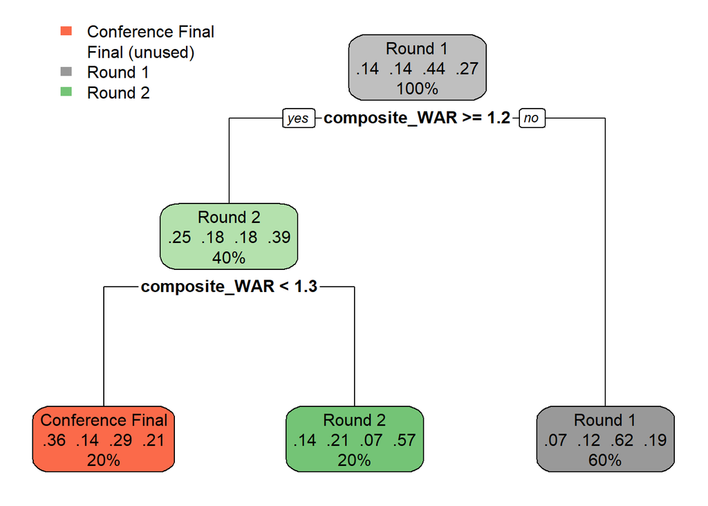

The model has been trained. We now visualize the tree.

## Results and Discussion

Random Forest Confusion Matrix

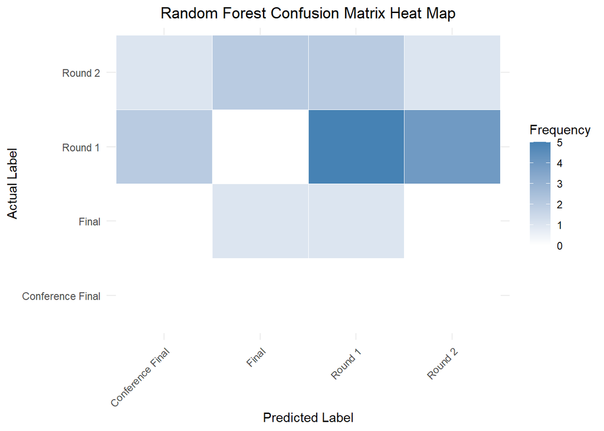

Decision Tree Confusion Matrix

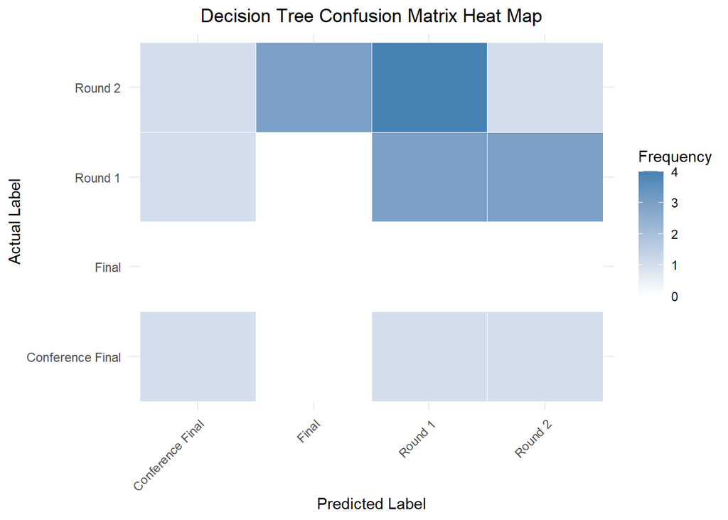

KNN Confusion Matrix

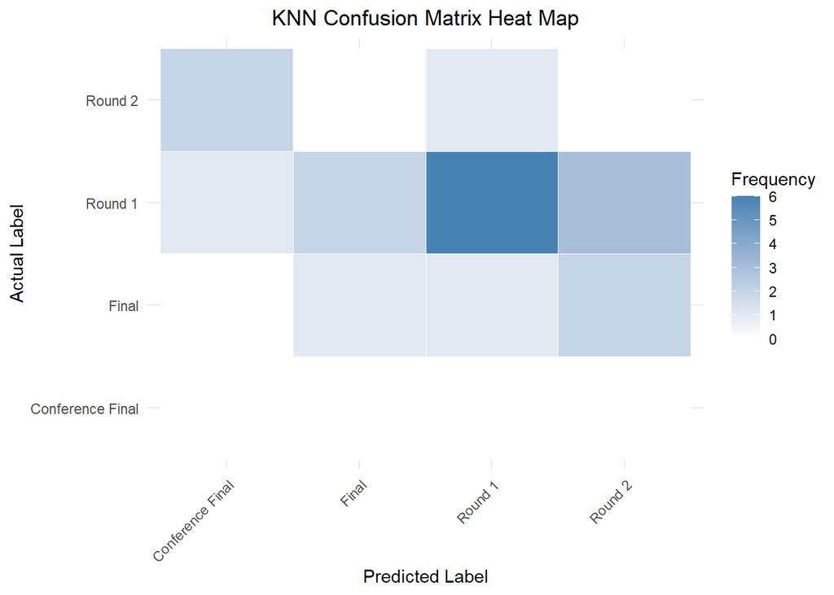

Histogram of class distribution

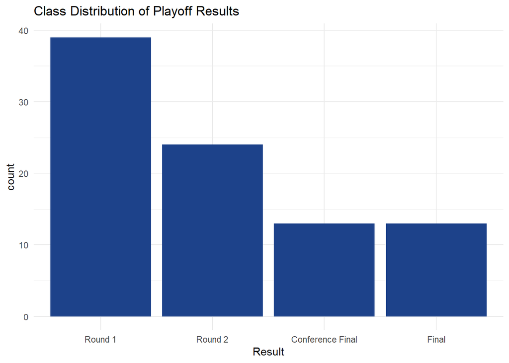

There are some key weaknesses of our analysis: size constraints of the dataset, class imbalance, model selection, and variable selection.

The size and constraints of the dataset, which only contained roughly 100 data points, had a substantial impact on the conclusions of our investigation. A relatively small sample size will inevitably cause the model to not train properly as the model will not have enough data to train on. Unfortunately, this is not something that can be directly fixed (e.g. by harvesting more data), as RAPTOR data is only available from 2014-2021 and is not currently maintained.

Our models used categorical classifiers rather than ordinal categorical classifiers, which could be more representative of the NBA playoffs’ evolution. The selection of models, such as Random Forest and KNN, may not have been ideal. Multinomial models or gradient boosting methods (GBMs) may have produced better results. Predicting NBA playoff outcomes is inherently complex and cannot be effectively reduced to just five variables. We also assumed that the RAPTOR data, a subjective assessment of player performance, was reliable, and that Average WAR accurately represented a team’s overall success. However, these assumptions may not hold true in practice, thus introducing extra flaws into the analysis.

In conclusion, the chosen dataset suffered from its small size, there was significant class imbalance, the models selected used categorical instead of ordinal categorical classifiers, and the variables selected as predictors did not reflect the complexity of the NBA playoffs. The poor accuracy scores highlighted these shortcomings, demonstrating the models’ inability to address our research question’s complexity. More robust datasets, alternate categorization methods, and other features may result in better performance.

## Reflection, Acknowledgement, and References

Coming to a consensus on selecting the ideal models that could use our data to produce the highest percentage of successful predictions was challenging. There wasn’t an ideal model that could achieve optimal accuracy for our results due to the amount of limitations that were present when running the RF/KNN tests, such as subpar alignment within the confusion matrices as well as being restricted to only 5 variables for the tests that were run. Extensive discussions and experimentation were required to explore various models such as logistic or linear regression and to strike a balance between the type of data we had, performance of the model, and feasibility.

Through this project, we learned that predicting NBA playoff results, particularly with the datasets we utilized, was not easily possible by taking only five variables into account. Even with the addition of more related variables, such as steals or points, the models would never be able to paint an accurate picture of the result of a basketball game due to the sheer number of factors involved in the outcome, some of which could not be reproduced into data. For example, although it would certainly influence the outcome of the game, iit would be difficult to find or manually gather data on the mental state of every player before and during the match. This process emphasized the importance of robust data preparation and the importance of choosing the correct model based on the type of data we had gathered, teaching us how to navigate the challenges of working with complex datasets and imbalanced classifications.

The success of the project would not have been possible without the collaborative efforts of all team members. Swara was able to merge the datasets containing team names, years, Wins Above Replacement (WAR), regular season wins, and team rank spanning the 2014-2021 NBA seasons. She incorporated regular season wins data by joining it with the team rank dataset on abbreviations and year, creating a dataframe that matched each full team name to its respective abbreviation. She also wrote the data preparation section of the research report.

Daniel added the conference for each team and their true shooting percentages to the dataset Swara created. To achieve this, Daniel mapped the conferences to each team within Swara’s abbreviation dataframe and joined datasets containing true shooting percentages for the respective seasons with Swara’s dataset. He contributed his additions to the data preparation section of the research report.

Lan primarily focused on creating the KNN model to interpret the results across the merged datasets and predict playoff performance. He wrote the KNN model and performed model testing to evaluate which provided the best performance in terms of predicting playoff outcomes. He also created a histogram that displayed the distribution of teams advancing through each round, from Round 1 to Finals, to emphasize how our models had less data to base predictions off of after every round of cuts within the playoff season. Lan wrote the introduction and the information related to the KNN model on the research report. Finally, Lan reviewed the code written by all team members to ensure efficiency and reproducibility.

Lilliana created the Random Forest model as an alternative to the KNN model and the Decision Tree model to create predictions on the playoff performance of the NBA teams. She also wrote the code for the Confusion matrices and heatmap associated with all the models to provide a visual representation of the inaccuracies our models contained in predicting the outcomes of NBA playoff season games.

References: Kandell, Jake. “JakeKandell/NBA-Predict.” GitHub, GitHub, 2019, github.com/JakeKandell/NBA-Predict. Houde, Matthew. “Predicting the Outcome of NBA Games Predicting the Outcome of NBA Games”. Bryant Digital Repository, Bryant University, 2021. Basketball Reference: basketball-reference.com RAPTOR score: https://github.com/fivethirtyeight/data/tree/master/nba-raptor